# 政治学方法論 I

線形回帰（1）

矢内 勇生

2016年5月18日

### 準備

まず、必要なパッケージを読み込む。インストールが必要なら先にインストールする。

```r
library("foreign")
library("dplyr")
library("arm")
library("ggplot2")
## Windows ユーザは次の行をコメントアウト
theme_set(theme_gray(base_size = 12, base_family = "HiraKakuProN-W3"))
```

説明のために『Stataによる計量政治学』（浅野正彦, 矢内勇生. 2013）で使用されているデータ（hr96-09.dta） を使う。 まず、このデータを読み込む（データへのパスは各自の状況に応じて変えること。ここでは、RStudioのプロジェクトを利用していて、プロジェクトが存在するフォルダ内にdata という名前のフォルダがあり、その中にデータセットが保存されていると仮定している）。

Rは、他の統計分析ソフト用のデータファイルも読み込むことができる。Stata のデータファイル（拡張子が.dtaのファイル）は、`foreign::read.dta()` または `haven::read_dta()` を使って読み込める。

```r
HR <- read.dta("data/hr96-09.dta")
head(HR)
```

```
##   year    ku kun party              name age     status nocand   wl rank
## 1 1996 aichi   1   NFP KAWAMURA, TAKASHI  47  incumbent      7  win    1
## 2 1996 aichi   1   LDP     IMAEDA, NORIO  72       moto      7 lose    2
## 3 1996 aichi   1   DPJ     SATO, TAISUKE  53  incumbent      7 lose    3
## 4 1996 aichi   1   JCP   IWANAKA, MIHOKO  43 challenger      7 lose    4
## 5 1996 aichi   1 bunka       ITO, MASAKO  51 challenger      7 lose    5
## 6 1996 aichi   1    NP  YAMADA, HIROSHIB  51 challenger      7 lose    6
##   previous  vote voteshare eligible turnout     exp
## 1        2 66876      40.0   346774   49.22 9828097
## 2        3 42969      25.7   346774   49.22 9311555
## 3        2 33503      20.1   346774   49.22 9231284
## 4        0 22209      13.3   346774   49.22 2177203
## 5        0   616       0.4   346774   49.22      NA
## 6        0   566       0.3   346774   49.22      NA
```

```r
tail(HR)
```

```
##      year        ku kun party                name age     status nocand
## 5609 2009 yamanashi   2   msz    NAGASAKI, KOTARO  41  incumbent      4
## 5610 2009 yamanashi   2   LDP    HORIUCHI, MITSUO  79  incumbent      4
## 5611 2009 yamanashi   2     H MIYAMATSU, HIROYUKI  69 challenger      4
## 5612 2009 yamanashi   3   DPJ       GOTO, HITOSHI  52  incumbent      3
## 5613 2009 yamanashi   3   LDP           ONO, JIRO  56  incumbent      3
## 5614 2009 yamanashi   3     H   SAKURADA, DAISUKE  47 challenger      3
##        wl rank previous   vote voteshare eligible turnout      exp
## 5609 lose    2        1  57213      32.1   234746   77.09  7916556
## 5610 lose    3       10  52773      29.6   234746   77.09 11611677
## 5611 lose    4        0   1214       0.7   234746   77.09  1326378
## 5612  win    1        3 112894      62.7   248102   74.70  6795969
## 5613 lose    2        1  63611      35.3   248102   74.70 12876644
## 5614 lose    3        0   3663       2.0   248102   74.70  1953819
```

衆議院議員経験があることを表すダミー変数と選挙費用を100万円単位で測定する変数を作る。

```r
HR <- HR %>%
    mutate(experience = as.numeric(status == "incumbent" | status == "moto"),
           expm = exp / 10^6)
```

2009年の結果だけ抜き出し、HR09として保存する。

```r
HR09 <- HR %>% filter(year == 2009)
```

## Rで線形回帰分析を行う

### 予測変数が二値しかとらないとき（モデル1）

得票率（応答変数）を議員経験（予測変数）で説明するモデルを考えよう。 議員経験は、現職または元職の候補者なら1、そうでなければ0をとる二値 (binary) 変数（ダミー変数）である。 このモデルを式で表すと、
$$得票率_i \sim \mathrm{N}(\beta_1 + \beta_2 \cdot 議員経験_i, \sigma^2)$$
と、なる。

Rでは、`lm()` で回帰式を推定する。

```r
fit_1 <- lm(voteshare ~ experience, data = HR09)
```

これで、`fit_1` に推定結果（係数の推定値など）が保存される。

基本的な結果は、`summary()` で見ることができる。

```r
summary(fit_1)
```

```
##
## Call:
## lm(formula = voteshare ~ experience, data = HR09)
##
## Residuals:
##     Min      1Q  Median      3Q     Max
## -43.843 -12.134  -5.484   8.707  52.016
##
## Coefficients:
##             Estimate Std. Error t value Pr(>|t|)
## (Intercept)  13.9840     0.6221   22.48   <2e-16
## experience   30.8589     0.9832   31.39   <2e-16
##
## Residual standard error: 16.26 on 1137 degrees of freedom
## Multiple R-squared:  0.4642, Adjusted R-squared:  0.4637
## F-statistic:   985 on 1 and 1137 DF,  p-value: < 2.2e-16
```

この結果は少し読みにくいので、代わりに `arm::display()` を利用しよう。

```r
display(fit_1)
```

```
## lm(formula = voteshare ~ experience, data = HR09)
##             coef.est coef.se
## (Intercept) 13.98     0.62
## experience  30.86     0.98
## ---
## n = 1139, k = 2
## residual sd = 16.26, R-Squared = 0.46
```

この出力の、**coef.est** の列に係数の推定値 (coefficient estimates) が示されている。 これにより、$\hat{\beta}_1=$ 13.98, $\hat{\beta}_2=$ 30.86, $\hat{\sigma}=$ 16.26 が得られた。 したがって、
$$\widehat{得票率} = 13.98 + 30.86 \cdot 議員経験$$
と、なる。

この結果を図示しよう。

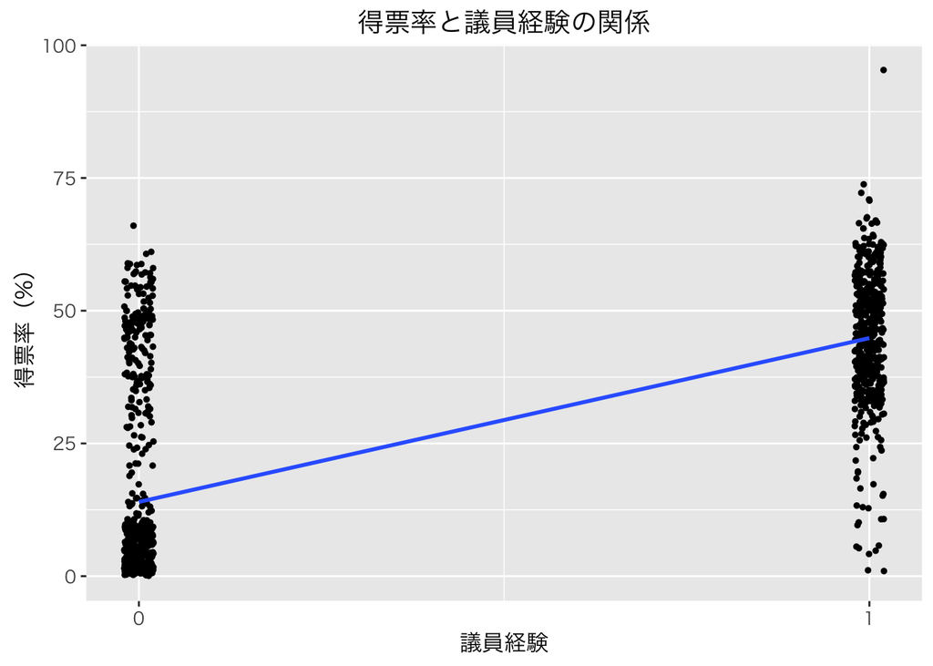

```r
p1 <- ggplot(HR09, aes(x = experience, y = voteshare)) +
    scale_x_continuous(breaks = c(0,1))
p1 <- p1 + geom_jitter(position = position_jitter(width = 0.05), size = 1)
p1 <- p1 + geom_smooth(method = 'lm', se = FALSE) +
    xlab('議員経験') + ylab('得票率（%）')
print(p1 + ggtitle('得票率と議員経験の関係'))
```

この図に推定の不確実性を示すには、`geom_smooth(method = 'lm', se = TRUE)` とすればよい（が、 se = TRUE はデフォルトなので、seを指定する必要はない）。 デフォルトでは、95パーセント信頼区間（HPDIではない）が回帰直線の周りに表示される。

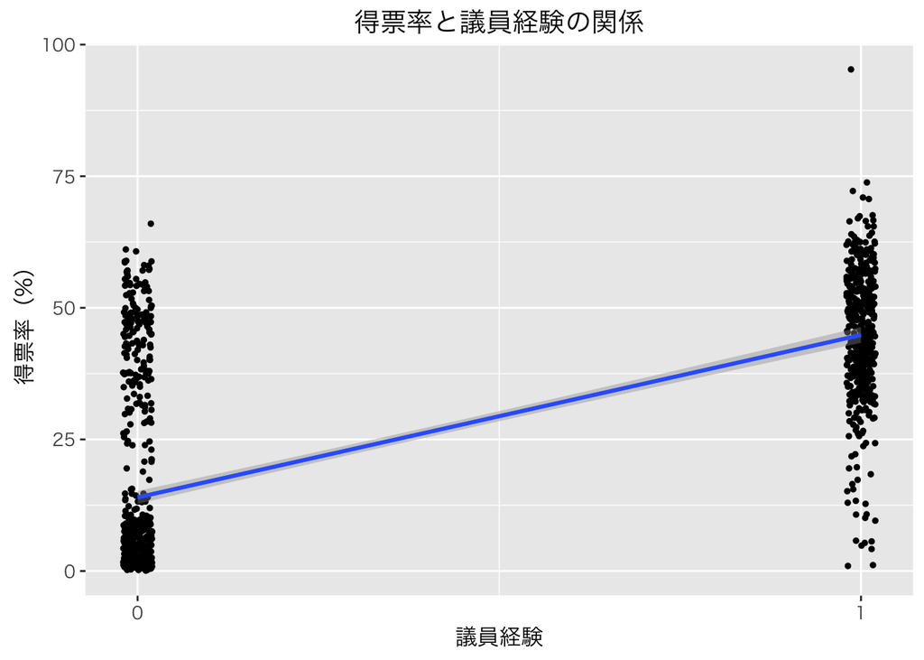

```r
p1_ci95 <- p1 + geom_smooth(method = 'lm')
print(p1_ci95 + ggtitle('得票率と議員経験の関係'))
```

信頼度を変えたいとき、例えば50パーセント信頼区間を表示したいときは、次のように**level**を指定する。

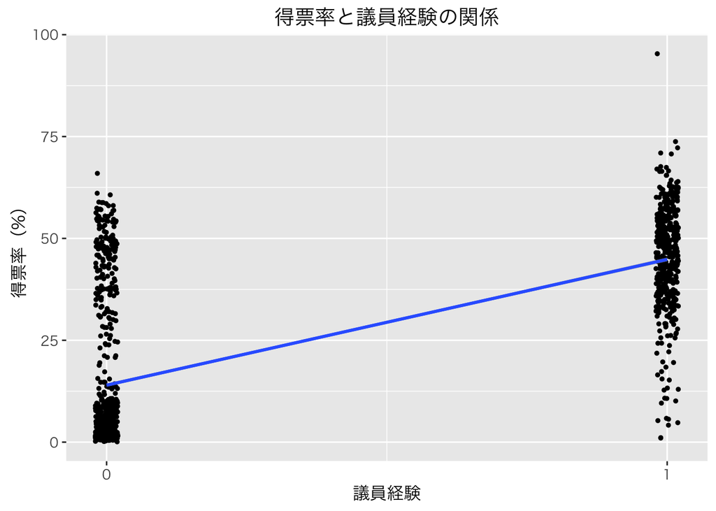

```r
p1_ci50 <- p1 + geom_smooth(method = 'lm', level = .5)
print(p1_ci50 + ggtitle('得票率と議員経験の関係'))
```

この直線の切片である13.98は、議員経験がない候補者の平均得票率（予測得票率）である。 予測値の式の「議員経験」に0を代入すれば、これは明らかである。 議員経験がある候補者の平均得票率（予測得票率）は、「議員経験」に1を代入することで得られる。 代入してみると、$13.98 + 30.86 \cdot 1 = 44.84$ となる。

Rで議員経験ごとに平均得票率を求め、上の式から求めた予測値と一致するか確かめよう。

```r
HR09 %>% group_by(experience) %>%
    summarize(voteshare = mean(voteshare))
```

```
## Source: local data frame [2 x 2]
##
##   experience voteshare
##        (dbl)     (dbl)
## 1          0  13.98404
## 2          1  44.84298
```

このように、予測値は予測変数の値を与えられたときの、応答変数の平均値であることがわかる。

### 予測変数が連続値をとるとき（モデル2）

同様に、得票率を選挙費用（測定単位：100万円）で説明するモデルは、次のように推定できる。

```r
fit_2 <- lm(voteshare ~ expm, data = HR09)
display(fit_2)
```

```
## lm(formula = voteshare ~ expm, data = HR09)
##             coef.est coef.se
## (Intercept) 7.74     0.76
## expm        3.07     0.10
## ---
## n = 1124, k = 2
## residual sd = 16.04, R-Squared = 0.48
```

回帰直線を図示する。

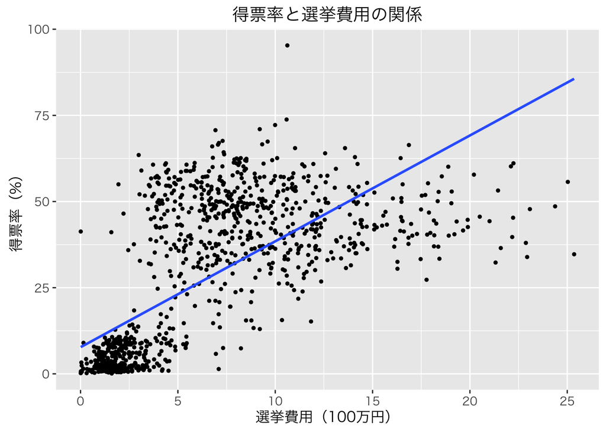

```r
p2 <- ggplot(HR09, aes(x = expm, y = voteshare)) + geom_point(size = 1)
p2 <- p2 + geom_smooth(method = 'lm', se = FALSE)
p2 <- p2 + labs(x = '選挙費用（100万円）', y = '得票率（%）')
print(p2 + ggtitle('得票率と選挙費用の関係'))
```

95パーセント信頼区間（HPDIではない）を加える。

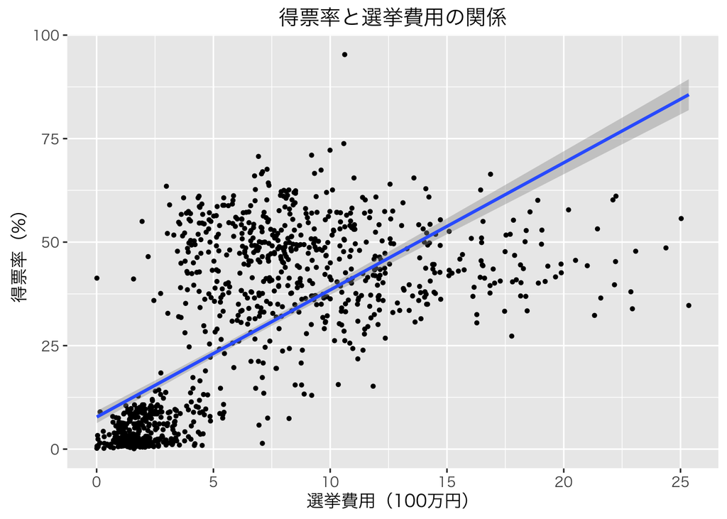

```r
p2_ci95 <- p2 + geom_smooth(method = 'lm')
print(p2_ci95 + ggtitle('得票率と選挙費用の関係'))
```

### 複数の予測変数を使った回帰（モデル3）

次に、得票率を議員経験と選挙費用で説明するモデルを推定する。 `lm()` で重回帰を行うときは、予測変数を **+** でつなぐ。

```r
fit_3 <- lm(voteshare ~ experience + expm, data = HR09)
display(fit_3)
```

```
## lm(formula = voteshare ~ experience + expm, data = HR09)
##             coef.est coef.se
## (Intercept)  7.91     0.69
## experience  18.10     1.23
## expm         1.85     0.12
## ---
## n = 1124, k = 3
## residual sd = 14.69, R-Squared = 0.56
```

この結果を図示する。

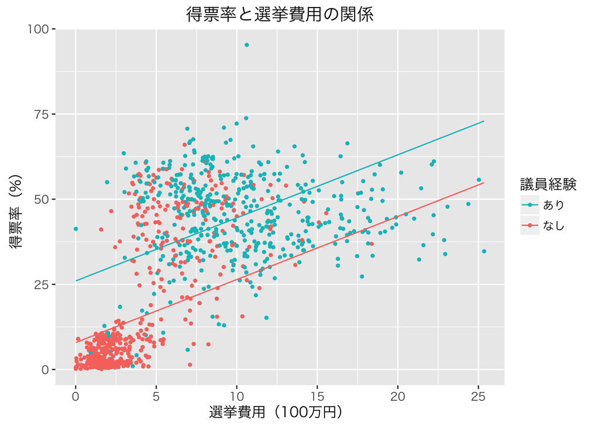

```r
## 予測値のデータフレームを作る
pred <- with(HR09, expand.grid(
    expm = seq(min(expm, na.rm = TRUE), max(expm, na.rm = TRUE), length.out = 100),
    experience = c(0,1)
    ))
## 予測値を計算する
pred <- mutate(pred, voteshare = predict(fit_3, newdata = pred))
## 散布図 (point) は元データ (HR09) で描き、回帰直線は予測値 (pred) で描く
p3 <- ggplot(HR09, aes(x = expm, y = voteshare, color = as.factor(experience))) +
    geom_point(size = 1) +
    geom_line(data = pred)
p3 <- p3 + labs(x = '選挙費用（100万円）', y = '得票率（%）')
p3 <- p3 +
    scale_color_discrete(name = '議員経験', labels = c('なし', 'あり')) +
    guides(color = guide_legend(reverse = TRUE))
print(p3 + ggtitle('得票率と選挙費用の関係'))
```

この図からわかるように、このモデルは2つの直線が平行になる（傾きが同じになる）ように**設定されて**いる。

この図に95パーセント信頼区間（HPDIではない）を加える。 信頼区間を求めるために標準誤差を利用する。 また、標準誤差は$t$ 分布に従うので、`qt()` で分布の95%が収まる範囲を求める （標準正規分布で近似し、$\pm 1.96$ を使っても結果に大きな違いはないが、せっかくRを使っているのだから、より正確な数値を利用したほうがよい）。

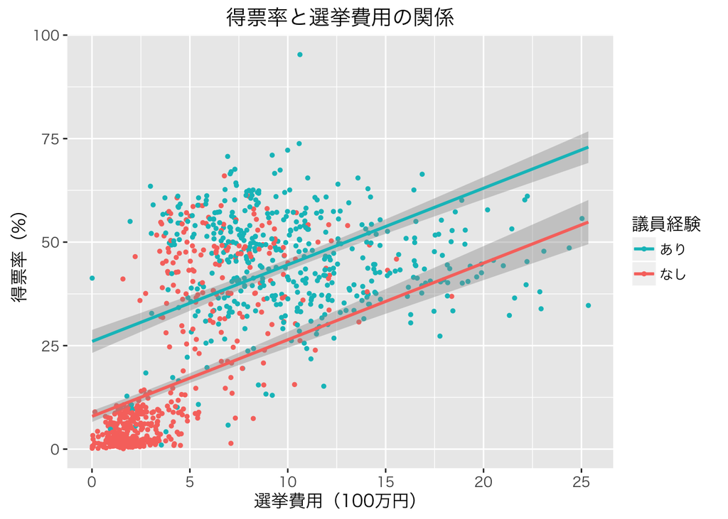

```r
## 信頼区間の下限と上限を計算する
## まず、予測値と標準誤差を求める
err <- predict(fit_3, newdata = pred, se.fit = TRUE)
## 予測値と標準誤差を使って信頼区間を求める
pred$lower <- err$fit + qt(0.025, df = err$df) * err$se.fit
pred$upper <- err$fit + qt(0.975, df = err$df) * err$se.fit

p3_ci95 <- p3 +
    geom_smooth(data = pred, aes(ymin = lower, ymax = upper), stat = 'identity')
print(p3_ci95 + ggtitle('得票率と選挙費用の関係'))
```

### 相互作用を考える（モデル4）

モデル3では回帰直線が平行になるようにモデルを制限していたが、この制限を緩めてみよう。 そのために、議員経験 $\times$ 選挙費用という予測変数を追加する。

Rでは、`lm()` 内の予測変数のところに、`変数A * 変数B` と書くと、変数A、変数B、変数A $\times$ 変数B を予測変数として加えてくれるので、これを利用する。

```r
fit_4 <- lm(voteshare ~ experience * expm, data = HR09)
display(fit_4)
```

```
## lm(formula = voteshare ~ experience * expm, data = HR09)
##                 coef.est coef.se
## (Intercept)     -2.07     0.72
## experience      45.91     1.58
## expm             4.87     0.16
## experience:expm -4.76     0.21
## ---
## n = 1124, k = 4
## residual sd = 12.11, R-Squared = 0.70
```

この結果を図示する。

[figure not shown]

95パーセント信頼区間（HPDIではない）を加える。

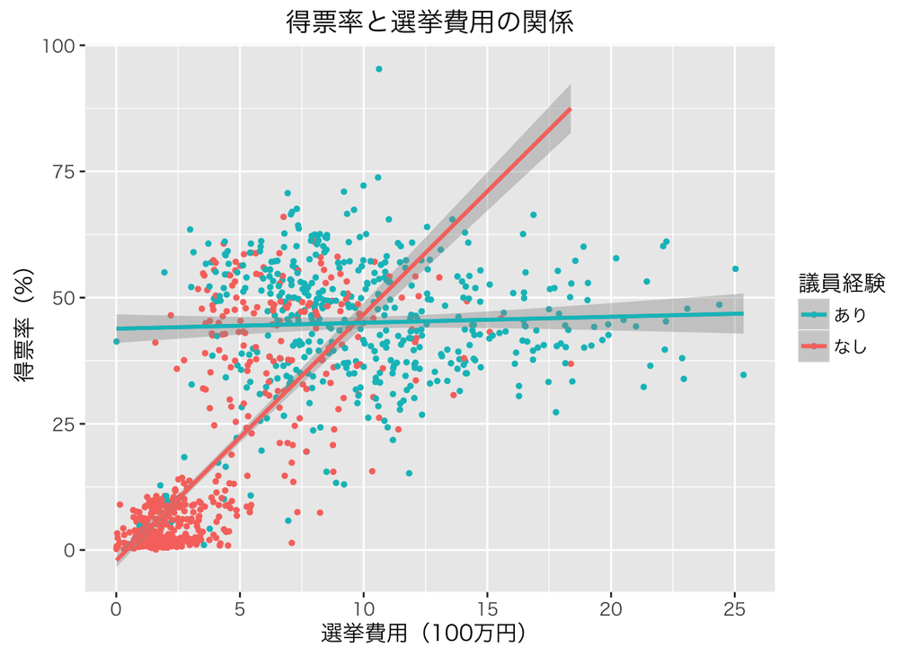

```r
p4_ci95 <- p4 + geom_smooth(method = 'lm')
print(p4_ci95 + ggtitle('得票率と選挙費用の関係'))
```

## シミュレーションで回帰分析を理解する

回帰分析のしくみ（特に信頼区間の意味）を理解するために、簡単なモンテカルロシミュレーションを行おう。 シミュレーションでは、自分で母数を設定し、データを生成する。 そのうえで、特徴を知りたい分析手法（今回の場合はOLS）を生成したデータに当てはめ、母数をうまく推測できるかどうか確認する。

今回は、単回帰を例にシミュレーションを行う。 このシミュレーションを行う主な目的は以下の3つである。

1. 線形回帰が想定するデータ生成過程 (data generating process) を理解する
2. 線形回帰の推定量の基本的な性質を理解する
3. 信頼区間の意味を理解する

単回帰モデルは
$$y \sim \mathrm{N}(X\beta, \sigma^2 I)$$
または、
$$y_i \sim \mathrm{N}(\beta_1 + \beta_2 x_i, \sigma^2)$$
($i = 1, 2, \dots, n$)と表すことができる。 したがって、設定する母数は3つある。

```r
beta1 <- 10   # 切片の値を決める
beta2 <- 3    # 傾き（予測変数の係数）を決める
sigma <- 6    # 誤差の標準偏差を決める
```

次に、単回帰モデルが想定する**データ生成過程**に従って、データを生成する。

```r
n <- 100   ## サンプルサイズを決める
## x ~ U(0, 10) とする：他の設定でもかまわない
x <- runif(n, 0, 10)   ## 最小値0, 最大値10の一様分布から長さnのxベクトルを抽出する
y <- rnorm(n, beta1 + beta2 * x, sd = sigma)  ## 設定に従って、yを正規分布から抽出する
```

ここで、手に入れたデータを散布図にして直線を当てはめてみよう。

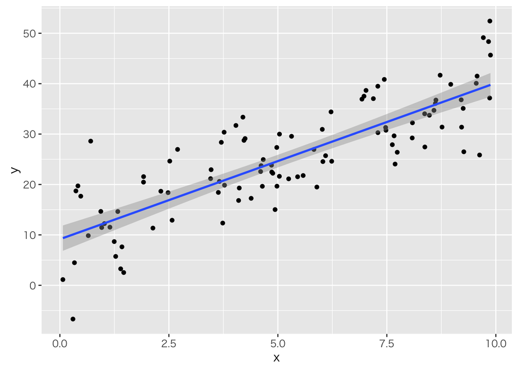

```r
df <- data.frame(y, x)
scat <- ggplot(df, aes(x, y)) + geom_point() + geom_smooth(method = 'lm')
print(scat)
```

回帰式を推定すると、

```r
eg_1 <- lm(y ~ x, data = df)
display(eg_1)
```

```
## lm(formula = y ~ x, data = df)
##             coef.est coef.se
## (Intercept) 9.14     1.28
## x           3.10     0.22
## ---
## n = 100, k = 2
## residual sd = 6.29, R-Squared = 0.68
```

3つの母数$\beta_1=10, \beta_2=3, \sigma=6$ に対する推定値は、それぞれ9.14, 3.1, 6.29 であることがわかる。

このとき、係数の95パーセント信頼区間は、

```r
confint(eg_1)
```

```
##                2.5 %    97.5 %
## (Intercept) 6.602367 11.686254
## x           2.672670  3.526034
```

で求められる。 95パーセント信頼区間は、切片が[6.60, 11.69]、傾きが[2.67, 3.53] であり、どちらの信頼区間も母数を含んでいる。 つまり、ここで得られた信頼区間が母数を含む確率は1（100%）である！

以上の過程を、母数とサンプルサイズは変えずに何度も繰り返す。 同じコードを何度も繰り返し使うのは面倒なので、関数にしてしまおう。

```r
sim_ols1 <- function(beta, sigma, n = 100, trials = 10000, x_rng = c(0,10)) {
    ## Function to simulate simple linear regressions
    ## Arguments:
    ##   beta: vector of coefficient parameters
    ##   sigma: standard deviation of the error
    ##   n: sample size, default n=100
    ##   trials: the number of simulation trials
    ##           default trials=10000
    ##   x_rng: range of the explanatory variable x
    ##          default x.rng=c(0,10)
    ## Return:
    ##   df: data frame containing
    ##      (1) parameter estimates,
    ##      (2) se of coefficient estimates, and
    ##      (3) 95% CI of coefficient estimates
    ##      for each trial of the simulation.

    ## create a data frame to save the results
    col_names <- c('b1', 'b1_se', 'b1_lower', 'b1_upper',
                   'b2', 'b2_se', 'b2_lower', 'b2_upper', 'sigma_hat')
    df <- as.data.frame(matrix(rep(NA, trials * length(col_names)),
                               ncol = length(col_names)))
    names(df) <- col_names

    for (i in 1:trials) { # loop for trials
        # generate data
        x <- runif(n, x_rng[1], x_rng[2])
        y <- rnorm(n, mean = beta[1] + beta[2]*x, sd = sigma)

        # regress y on x
        fit <- lm(y ~ x)

        # sum of squared residuals
        sigma_hat <- summary(fit)$sigma

        # coefficient estimates
        b1 <- coef(fit)[1]
        b2 <- coef(fit)[2]

        # standard errors of coefficient estimates
        b1_se <- sqrt(summary(fit)$cov.unscaled[1,1]) * sigma_hat
        b2_se <- sqrt(summary(fit)$cov.unscaled[2,2]) * sigma_hat

        # 95% CI
        b1_ci95 <- confint(fit)[1,]
        b2_ci95 <- confint(fit)[2,]

        # save the results
        df[i,] <- c(b1, b1_se, b1_ci95,
                    b2, b2_se, b2_ci95,
                    sigma_hat)
    }
    # return the data frame
    return(df)
}
```

この関数を利用して、実際にシミュレーションを行ってみよう。 自分で母数とサンプルサイズ（ここでは規定値のn=100を利用）を指定し、データの生成と回帰式の推定を1,000回繰り返すことにする。

```r
beta1 <- 10; beta2 <- 3; sigma <- 6
sim_1 <- sim_ols1(beta = c(beta1, beta2), sigma = sigma, trials = 1000)
head(sim_1)
```

```
##          b1    b1_se b1_lower b1_upper       b2     b2_se b2_lower
## 1 10.519381 1.333821 7.872455 13.16631 2.840636 0.2276824 2.388807
## 2  9.195160 1.558476 6.102415 12.28790 3.157845 0.2427141 2.676187
## 3  8.675866 1.365326 5.966421 11.38531 3.169810 0.2311890 2.711023
## 4  9.693470 1.422950 6.869673 12.51727 2.911867 0.2347170 2.446079
## 5  8.809144 1.111461 6.603487 11.01480 3.040280 0.2021615 2.639097
## 6  9.211938 1.086019 7.056770 11.36711 3.375313 0.1891709 2.999909
##   b2_upper sigma_hat
## 1 3.292464  6.304427
## 2 3.639503  6.559746
## 3 3.628597  6.609825
## 4 3.377655  6.311905
## 5 3.441463  5.704105
## 6 3.750716  5.662732
```

これで、シミュレーションで得られた数字は**sim_1**に保存された。

### 係数の推定値を理解する

予測変数 $x$ の係数の推定値 b2 の分布を確認してみよう。 私たちは母数$\beta_2=3$であることを知っているが、この数値をうまく推定できるだろうか？

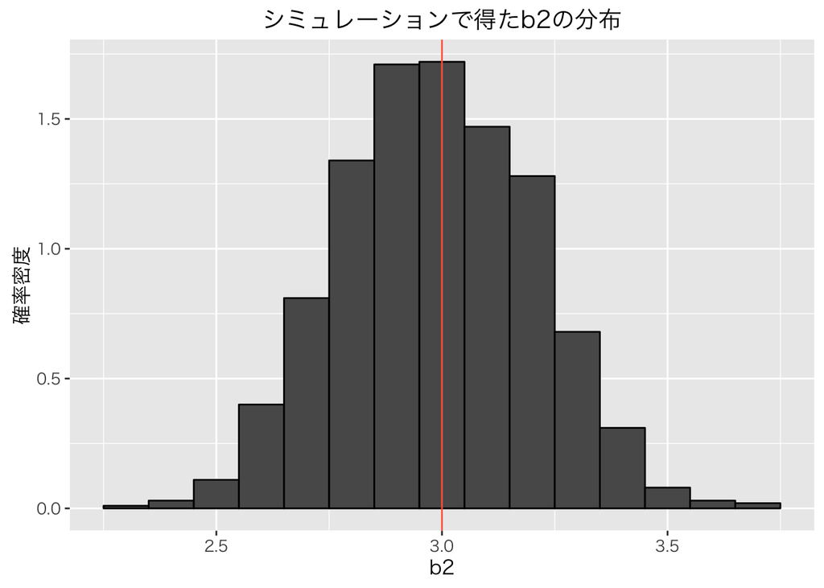

```r
hist_b2 <- ggplot(sim_1, aes(x = b2, y = ..density..)) +
    geom_histogram(binwidth = .1, color = 'black')
hist_b2 <- hist_b2 +
    labs(y = '確率密度', title = 'シミュレーションで得たb2の分布') +
    geom_vline(xintercept = 3, color = 'tomato')
print(hist_b2)
```

このヒストグラムが示すように、線形回帰は**平均すると**、母数をうまく推定してくれる（**不偏性, unbiasedness**）。しかし、常に正しい推定をするわけではなく、係数の値を過小推定することもあれば、過大推定することもある。実際の分析では、データセットが1つしかないのが普通であり、自分のデータ分析が係数を「正しく」推定しているとは限らならい。そのために、推定の不確実性を明示することが求められるのである。

### 標準誤差を理解する

次に、b2の標準誤差 (standar error) をヒストグラムにしてみよう。

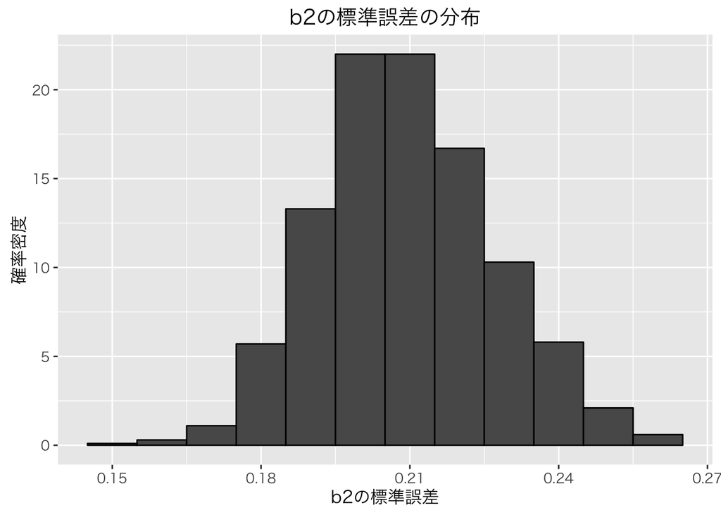

```r
hist_se <- ggplot(sim_1, aes(x = b2_se, y = ..density..)) +
    geom_histogram(binwidth = .01, color = 'black') +
    labs(x = 'b2の標準誤差', y = '確率密度', title = 'b2の標準誤差の分布')
print(hist_se)
```

このように、標準誤差自体が推定量なので、値はサンプルごとに異なる（分布する）。

標準誤差をseとすると、
$$\frac{\hat{\beta} - \beta}{\mathrm{se}}$$
は自由度$n-k$（ここでは、100-2=98）の$t$分布に従うはずである。 まず、この値をヒストグラムにして、自由度98の$t$分布の確率密度曲線を重ね書きしてみよう。

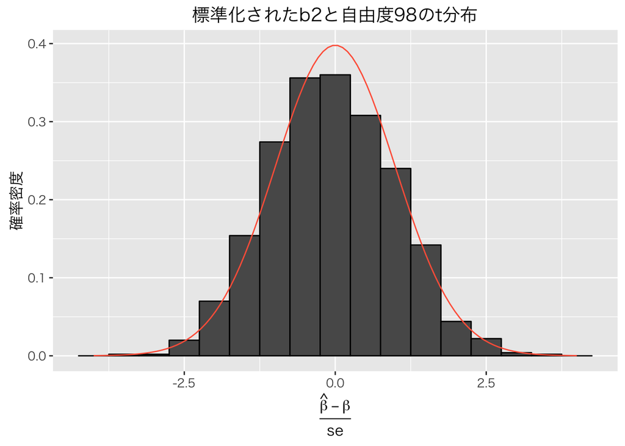

```r
sim_1 <- sim_1 %>% mutate(b2_t = (b2 - beta2) / b2_se)
## t分布の確率密度を求め、true_tという名前のデータフレームに保存する
true_t <- data.frame(x = seq(-4, 4, length = 100)) %>%
    mutate(density = dt(x, df = 98))
hist_t <- ggplot(sim_1, aes(x = b2_t, y = ..density..)) +
    geom_histogram(binwidth = 0.5, color = 'black') +
    geom_line(data = true_t, aes(x = x, y = density), color = 'tomato')
hist_t <- hist_t +
    labs(x = expression(frac(hat(beta) - beta, 'se')),
         y = '確率密度', title = '標準化されたb2と自由度98のt分布')
print(hist_t)
```

この図から、$t$分布に近い分布であることがわかる。 Q-Qプロットでも確かめてみよう。

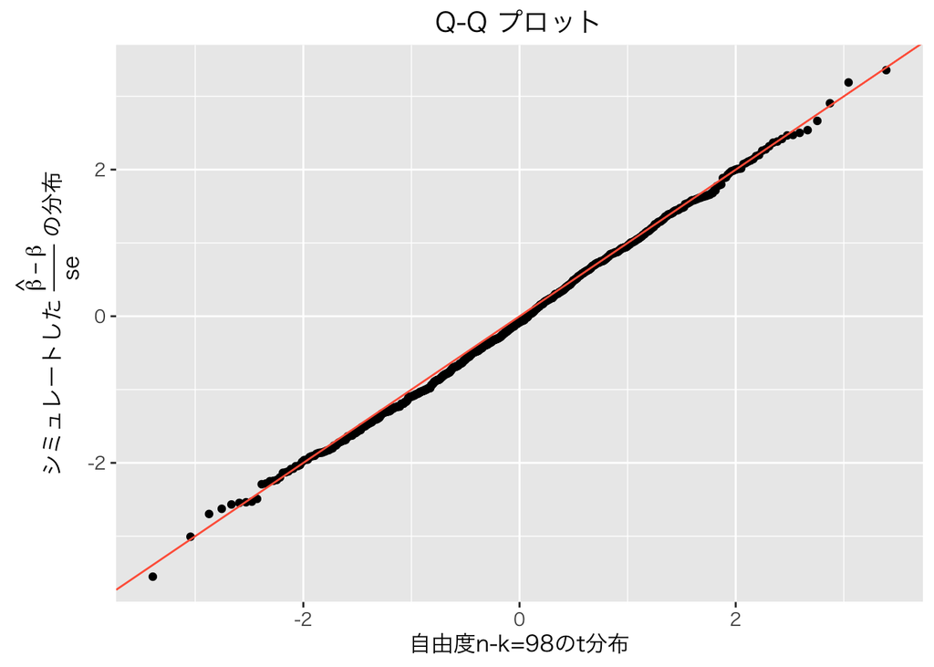

```r
qqplot_t <- ggplot(sim_1, aes(sample = b2_t)) +
    stat_qq(distribution = qt, dparams = list(df = 98)) +
    geom_abline(intercept = 0, slope = 1, color = 'tomato') +
    labs(title = 'Q-Q プロット',
         x = '自由度n-k=98のt分布',
         y = expression(paste('シミュレートした ', frac(hat(beta) - beta, 'se'), ' の分布')))
print(qqplot_t)
```

今回のシミュレーションで得られた標準誤差の平均値は、

```r
mean(sim_1$b2_se)
```

```
## [1] 0.209381
```

である。標準誤差は推定値の標準偏差のはずだが、本当にそうなっているかどうか確認してみよう。

```r
sd(sim_1$b2)
```

```
## [1] 0.2144247
```

これで、実際に標準誤差は推定値の標準偏差に（ほぼ）一致することがわかった。

### 信頼区間を理解する

係数の推定値b2の95パーセント信頼区間を例として考える。 シミュレーションで得られた1つ目の信頼区間は、

```r
sim_1[1, c('b2_lower', 'b2_upper')]
```

```
##   b2_lower b2_upper
## 1 2.388807 3.292464
```

すなわち、[2.39, 3.29] がb2[1] の95パーセント信頼区間である。 この区間は母数である$\beta_2=3$を区間内に含んでいる。 したがって、**この信頼区間が母数を含む確率は1（100%)である**。

同様に、2つ目の信頼区間は、

```r
sim_1[2, c('b2_lower', 'b2_upper')]
```

```
##   b2_lower b2_upper
## 2 2.676187 3.639503
```

であり、これも母数を区間内に含んでいる。

しかし、39番目の信頼区間は、

```r
sim_1[39, c('b2_lower', 'b2_upper')]
```

```
##    b2_lower b2_upper
## 39 3.025416 3.749442
```

であり、これは母数を区間内に含んでいない。 つまり、**この信頼区間が母数を含む確率は0である**。

シミュレーションで得た1,000個の信頼区間のうち、どの信頼区間が母数を含んでいるか調べてみよう。 母数を信頼区間内に含むのは、信頼区間の下限値が母数以下かつ上限値が母数以上のものである。

```r
check_ci <- sim_1$b2_lower <= beta2 & sim_1$b2_upper >= beta2
```

この結果、**TRUE**となっているものが母数を区間内に捉えているもの、**FALSE**がそうでないものである。これを表にすると、

```r
table(check_ci)
```

```
## check_ci
## FALSE  TRUE
##    49   951
```

と、なる。つまり、1000個の95パーセント信頼区間のうち、951個（95.1%）は母数を区間内に捉え、残りの49個が捉えないということである。このように、一定のデータ生成過程から得られた異なるデートセットに対し、信頼区間を求める作業を繰り返したとき、「得られた信頼区間のうち何パーセントが母数を区間内に含むか」というのが、信頼区間の信頼度である。

これを図にしてみよう。 1000個は多すぎるので、無作為に100個だけ選んで図示する。

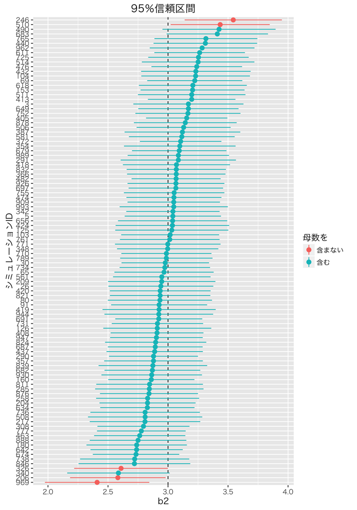

```r
# Give an ID to each simulated result
sim_1 <- sim_1 %>% mutate(id = 1:n())
# Put check_ci into the data frame
sim_1$check_ci <- check_ci
# Randomly choose 100 rows of sim values for graph
sim_1_sml <- sim_1 %>% sample_n(100)
# Show simulated ci's graphically
ctplr <- ggplot(sim_1_sml,
                aes(x = reorder(id, b2), y = b2,
                    ymin = b2_lower, ymax = b2_upper,
                    color = check_ci)) +
    geom_hline(yintercept = beta2, linetype = 'dashed') +
    geom_pointrange() +
    labs(x = 'シミュレーションID', y = 'b2', title = '95％信頼区間') +
    scale_color_discrete(name = '母数を', labels = c('含まない', '含む')) +
    coord_flip()
print(ctplr)
```

このように、100個中95個（95パーセント）の95パーセント信頼区間が、母数である3にかかっていることがわかる。

授業の内容に戻る